# Projet AirBNB

### Ce notebook est la version finale du projet, il contient seulement une partie des éléments de recherche, surtout en ce qui concerne la séléction et l'épluchage des données du dataset, afin d'éviter que celui-ci ne soit trop long et illisible.

Commençons par importer les différents bibliothèques dont nous allons nous servir pour exploiter le dataset et visualiser ses données

```python
import numpy as np
import pandas as pd
```

```python
data = pd.read_csv('airbnb_train.csv')
```

```python
data.head()
```

|  | id | log_price | property_type | room_type | amenities | accommodates | bathrooms | bed_type | cancellation_policy | cleaning_fee | ... | last_review | latitude | longitude | name | neighbourhood | number_of_reviews | review_scores_rating | zipcode | bedrooms | beds |
| --- | --- | --- | --- | --- | --- | --- | --- | --- | --- | --- | --- | --- | --- | --- | --- | --- | --- | --- | --- | --- | --- |
| 0 | 5708593 | 4.317488 | House | Private room | {TV,"Wireless Internet",Kitchen,"Free parking ... | 3 | 1.0 | Real Bed | flexible | False | ... | NaN | 33.782712 | -118.134410 | Island style Spa Studio | Long Beach | 0 | NaN | 90804 | 0.0 | 2.0 |
| 1 | 14483613 | 4.007333 | House | Private room | {"Wireless Internet","Air conditioning",Kitche... | 4 | 2.0 | Real Bed | strict | False | ... | 2017-09-17 | 40.705468 | -73.909439 | Beautiful and Simple Room W/2 Beds, 25 Mins to... | Ridgewood | 38 | 86.0 | 11385 | 1.0 | 2.0 |
| 2 | 10412649 | 7.090077 | Apartment | Entire home/apt | {TV,"Wireless Internet","Air conditioning",Kit... | 6 | 2.0 | Real Bed | flexible | False | ... | NaN | 38.917537 | -77.031651 | 2br/2ba luxury condo perfect for infant / toddler | U Street Corridor | 0 | NaN | 20009 | 2.0 | 2.0 |
| 3 | 17954362 | 3.555348 | House | Private room | {TV,"Cable TV",Internet,"Wireless Internet","A... | 1 | 1.0 | Real Bed | flexible | True | ... | 2017-09-29 | 40.736001 | -73.924248 | Manhattan view from Queens. Lovely single room . | Sunnyside | 19 | 96.0 | 11104 | 1.0 | 1.0 |
| 4 | 9969781 | 5.480639 | House | Entire home/apt | {TV,"Cable TV",Internet,"Wireless Internet",Ki... | 4 | 1.0 | Real Bed | moderate | True | ... | 2017-08-28 | 37.744896 | -122.430665 | Zen Captured Noe Valley House | Noe Valley | 15 | 96.0 | 94131 | 2.0 | 2.0 |

5 rows × 28 columns

```python
data.tail()
```

|  | id | log_price | property_type | room_type | amenities | accommodates | bathrooms | bed_type | cancellation_policy | cleaning_fee | ... | last_review | latitude | longitude | name | neighbourhood | number_of_reviews | review_scores_rating | zipcode | bedrooms | beds |
| --- | --- | --- | --- | --- | --- | --- | --- | --- | --- | --- | --- | --- | --- | --- | --- | --- | --- | --- | --- | --- | --- |
| 22229 | 11989532 | 4.605170 | Apartment | Private room | {} | 1 | 1.0 | Real Bed | flexible | False | ... | NaN | 40.709025 | -73.939405 | one room bushwick | Williamsburg | 0 | NaN | 11206.0 | 1.0 | 1.0 |
| 22230 | 20652462 | 5.043425 | Apartment | Entire home/apt | {TV,"Cable TV",Internet,"Wireless Internet",Ki... | 4 | 2.0 | Real Bed | moderate | True | ... | 2017-04-15 | 33.871549 | -118.396053 | Spacious Hermosa 2 BR on PCH | Hermosa Beach | 16 | 93.0 | 90254 | 2.0 | 4.0 |
| 22231 | 12380210 | 5.220356 | Apartment | Entire home/apt | {TV,Internet,"Wireless Internet","Air conditio... | 5 | 1.0 | Real Bed | moderate | True | ... | 2017-09-10 | 40.706749 | -73.942377 | Modern 2 Bedroom Apartment in Williamsburg | Williamsburg | 43 | 94.0 | 11206.0 | 2.0 | 2.0 |
| 22232 | 19533966 | 5.273000 | Apartment | Entire home/apt | {TV,"Wireless Internet","Air conditioning",Kit... | 2 | 1.0 | Real Bed | strict | True | ... | NaN | 40.738535 | -74.000157 | Designer's Apartment in HEART of NYC | West Village | 0 | NaN | 10011 | 0.0 | 2.0 |
| 22233 | 18507240 | 4.852030 | Boat | Entire home/apt | {TV,Internet,"Wireless Internet",Kitchen,"Free... | 4 | 1.0 | Real Bed | moderate | False | ... | 2017-04-30 | 33.761096 | -118.192409 | Cozy Boat at Shoreline Village | Long Beach | 205 | 96.0 | 90802 | 1.0 | 2.0 |

5 rows × 28 columns

```python
data.info()
```

```
<class 'pandas.core.frame.DataFrame'>
RangeIndex: 22234 entries, 0 to 22233
Data columns (total 28 columns):
 #   Column                  Non-Null Count  Dtype
---  ------                  --------------  -----
 0   id                      22234 non-null  int64
 1   log_price               22234 non-null  float64
 2   property_type           22234 non-null  object
 3   room_type               22234 non-null  object
 4   amenities               22234 non-null  object
 5   accommodates            22234 non-null  int64
 6   bathrooms               22183 non-null  float64
 7   bed_type                22234 non-null  object
 8   cancellation_policy     22234 non-null  object
 9   cleaning_fee            22234 non-null  bool
```

[output cut: 20 more lines]

```python
data.describe() #description des valeurs numériques et du booléen cleaning_fee
```

|  | id | log_price | accommodates | bathrooms | latitude | longitude | number_of_reviews | review_scores_rating | bedrooms | beds |
| --- | --- | --- | --- | --- | --- | --- | --- | --- | --- | --- |
| count | 2.223400e+04 | 22234.000000 | 22234.000000 | 22183.000000 | 22234.000000 | 22234.000000 | 22234.000000 | 17256.000000 | 22208.000000 | 22199.000000 |
| mean | 1.122269e+07 | 4.783481 | 3.155573 | 1.236037 | 38.462971 | -92.269305 | 20.670774 | 94.069077 | 1.264769 | 1.711473 |
| std | 6.080480e+06 | 0.718758 | 2.143870 | 0.586246 | 3.071679 | 21.670081 | 37.183731 | 7.782235 | 0.852819 | 1.254903 |
| min | 3.362000e+03 | 2.302585 | 1.000000 | 0.000000 | 33.339002 | -122.510940 | 0.000000 | 20.000000 | 0.000000 | 0.000000 |
| 25% | 6.202924e+06 | 4.317488 | 2.000000 | 1.000000 | 34.136082 | -118.340633 | 1.000000 | 92.000000 | 1.000000 | 1.000000 |
| 50% | 1.217425e+07 | 4.700480 | 2.000000 | 1.000000 | 40.662632 | -76.994944 | 6.000000 | 96.000000 | 1.000000 | 1.000000 |
| 75% | 1.639502e+07 | 5.220356 | 4.000000 | 1.000000 | 40.746358 | -73.954599 | 23.000000 | 100.000000 | 1.000000 | 2.000000 |
| max | 2.120450e+07 | 7.600402 | 16.000000 | 8.000000 | 42.390248 | -70.989359 | 505.000000 | 100.000000 | 10.000000 | 18.000000 |

```python
data.describe(include='object') #description des valeurs de type 'object'
```

|  | property_type | room_type | amenities | bed_type | cancellation_policy | city | description | first_review | host_has_profile_pic | host_identity_verified | host_response_rate | host_since | instant_bookable | last_review | name | neighbourhood | zipcode |
| --- | --- | --- | --- | --- | --- | --- | --- | --- | --- | --- | --- | --- | --- | --- | --- | --- | --- |
| count | 22234 | 22234 | 22234 | 22234 | 22234 | 22234 | 22234 | 17509 | 22178 | 22178 | 16759 | 22178 | 22234 | 17518 | 22234 | 20148 | 21931 |
| unique | 31 | 3 | 21160 | 5 | 5 | 6 | 22169 | 2096 | 2 | 2 | 70 | 2852 | 2 | 1042 | 22155 | 558 | 674 |
| top | Apartment | Entire home/apt | {} | Real Bed | strict | NYC | Welcome to our unique shared space. This commu... | 2017-01-01 | t | t | 100% | 2015-03-30 | f | 2017-04-30 | East Village Studio | Williamsburg | 11211.0 |
| freq | 14635 | 12348 | 161 | 21622 | 9726 | 9739 | 3 | 88 | 22108 | 14953 | 13048 | 68 | 16401 | 420 | 4 | 878 | 425 |

#### Commencer par regarder si nous avons des cases NAN dans le dataset afin de les remplacer

```python
data.isna().sum()
```

```
id                           0
log_price                    0
property_type                0
room_type                    0
amenities                    0
accommodates                 0
bathrooms                   51
bed_type                     0
cancellation_policy          0
cleaning_fee                 0
city                         0
description                  0
first_review              4725
host_has_profile_pic        56
host_identity_verified      56
host_response_rate        5475
host_since                  56
instant_bookable             0
last_review               4716
latitude                     0
longitude                    0
name                         0
neighbourhood             2086
number_of_reviews            0
review_scores_rating      4978
zipcode                    303
bedrooms                    26
beds                        35
dtype: int64
```

On va remplacer ces NAN par "non-spécifié" dans les colonnes de type object

```python
colonnes_obj = data.select_dtypes(include=['object'])
data[colonnes_obj.columns] = colonnes_obj.fillna("non spécifié")
```

```python
data.isna().sum() #on vérifie que l'opération a bien fonctionné
```

```
id                           0
log_price                    0
property_type                0
room_type                    0
amenities                    0
accommodates                 0
bathrooms                   51
bed_type                     0
cancellation_policy          0
cleaning_fee                 0
city                         0
description                  0
first_review                 0
host_has_profile_pic         0
host_identity_verified       0
host_response_rate           0
host_since                   0
instant_bookable             0
last_review                  0
latitude                     0
longitude                    0
name                         0
neighbourhood                0
number_of_reviews            0
review_scores_rating      4978
zipcode                      0
bedrooms                    26
beds                        35
dtype: int64
```

Il nous reste maintenant à supprimer les NAN des colonnes numériques. Pour ce qui est de bathroom, bedrooms et beds, étant donné que l'on a très peu de valeur NAN, on va simplement les remplacer par zéro pour les salles de bain, car un logement peut ne pas en avoir, et un pour beds et bedroom, car un logement sans chambre ni lit ne fait pas de sens

```python
data['bathrooms'] = data['bathrooms'].fillna(0)
data['beds'] = data[['beds']].fillna(1)
data['bedrooms'] = data['bedrooms'].fillna(1)
```

```python
data.isna().sum() #on vérifie que l'opération a bien fonctionné
```

```
id                           0
log_price                    0
property_type                0
room_type                    0
amenities                    0
accommodates                 0
bathrooms                    0
bed_type                     0
cancellation_policy          0
cleaning_fee                 0
city                         0
description                  0
first_review                 0
host_has_profile_pic         0
host_identity_verified       0
host_response_rate           0
host_since                   0
instant_bookable             0
last_review                  0
latitude                     0
longitude                    0
name                         0
neighbourhood                0
number_of_reviews            0
review_scores_rating      4978
zipcode                      0
bedrooms                     0
beds                         0
dtype: int64
```

Occupons nous maintenant de review_score_rating

```python
log_price_nan = data[data['review_scores_rating'].isna()]['log_price']
log_price_not_nan = data[~data['review_scores_rating'].isna()]['log_price']

# Calcul des moyennes
mean_log_price_nan = log_price_nan.mean()
mean_log_price_not_nan = log_price_not_nan.mean()

# Affichage des résultats
print(f'Moyenne de log_price pour les lignes où review_scores_rating est NaN : {mean_log_price_nan}')
print(f'Moyenne de log_price pour les lignes où review_scores_rating n\'est pas NaN : {mean_log_price_not_nan}')
```

```
Moyenne de log_price pour les lignes où review_scores_rating est NaN : 4.904492584252595
Moyenne de log_price pour les lignes où review_scores_rating n'est pas NaN : 4.748571544829778
```

```python
intervalles = [(0,60),(60, 70), (70, 80), (80, 90), (90, 100)]

# Calculer la moyenne de log_price pour chaque intervalle
for debut, fin in intervalles:
    mask = (data['review_scores_rating'] >= debut) & (data['review_scores_rating'] < fin)
    mean_log_price = data[mask]['log_price'].mean()
    print(f'Moyenne de log_price pour review_scores_rating entre {debut} et {fin} : {mean_log_price}')
```

```
Moyenne de log_price pour review_scores_rating entre 0 et 60 : 4.534149611737768
Moyenne de log_price pour review_scores_rating entre 60 et 70 : 4.616218538254963
Moyenne de log_price pour review_scores_rating entre 70 et 80 : 4.552581198168095
Moyenne de log_price pour review_scores_rating entre 80 et 90 : 4.624402716017959
Moyenne de log_price pour review_scores_rating entre 90 et 100 : 4.761681261736472
```

On voit que pour les appartement dont le score est compris entre 60 et 90, la moyenne est relativement proche, mais qu'on constate un écart plus conséquent lorsqu'on passe à l'intervalle 90-->100

```python
intervals = [(90,95), (95, 100)]

# Calculer la moyenne de log_price pour chaque intervalle
for start, end in intervals:
    mask = (data['review_scores_rating'] >= start) & (data['review_scores_rating'] < end)
    mean_log_price = data[mask]['log_price'].mean()
    print(f'Moyenne de log_price pour review_scores_rating entre {start} et {end} : {mean_log_price}')
```

```
Moyenne de log_price pour review_scores_rating entre 90 et 95 : 4.724916179712066
Moyenne de log_price pour review_scores_rating entre 95 et 100 : 4.787032219891361
```

On remarque que la moyenne de log_price où review_scores_rating est NAN est supérieure à celle où le score est entre 90 et 100. On a près de 5000 valeurs où le score est NAN, ce qui représente près d'un cinquième du dataset. On va donc considérer que cette tendance est à suivre. On va donc remplacer review_scores_rating par des valeurs numériques plus explicites, en les regroupant comme suit : les valeurs entre 0 et 60 et celles entre 70 et 80 on une moyenne aux alentours de 4.54 : on va les regrouper et leurs assigner la valeur -2. Entre 60 et 70 et entre 80 et 90 : valeur -1. Entre 90 et 95 : valeur 0. Entre 95 et 100 : valeur 1. NaN : valeur 2.

```python
data['review_scores_rating'] =  np.where(data['review_scores_rating'].isna(), np.nan,
                                np.where(data['review_scores_rating'] < 60, -2,
                                np.where((data['review_scores_rating'] >= 60) & (data['review_scores_rating'] < 70), -1,
                                np.where((data['review_scores_rating'] >= 70) & (data['review_scores_rating'] < 80), -2,
                                np.where((data['review_scores_rating'] >= 80) & (data['review_scores_rating'] < 90), -1,
                                np.where((data['review_scores_rating'] >= 90) & (data['review_scores_rating'] < 95), 0,
                                np.where((data['review_scores_rating'] >= 95) & (data['review_scores_rating'] <= 100), 1,
                                data['review_scores_rating'])))))))
```

```python
data[['review_scores_rating']] = data[['review_scores_rating']].fillna(2);
```

```python
data.head()
```

|  | id | log_price | property_type | room_type | amenities | accommodates | bathrooms | bed_type | cancellation_policy | cleaning_fee | ... | last_review | latitude | longitude | name | neighbourhood | number_of_reviews | review_scores_rating | zipcode | bedrooms | beds |
| --- | --- | --- | --- | --- | --- | --- | --- | --- | --- | --- | --- | --- | --- | --- | --- | --- | --- | --- | --- | --- | --- |
| 0 | 5708593 | 4.317488 | House | Private room | {TV,"Wireless Internet",Kitchen,"Free parking ... | 3 | 1.0 | Real Bed | flexible | False | ... | non spécifié | 33.782712 | -118.134410 | Island style Spa Studio | Long Beach | 0 | 2.0 | 90804 | 0.0 | 2.0 |
| 1 | 14483613 | 4.007333 | House | Private room | {"Wireless Internet","Air conditioning",Kitche... | 4 | 2.0 | Real Bed | strict | False | ... | 2017-09-17 | 40.705468 | -73.909439 | Beautiful and Simple Room W/2 Beds, 25 Mins to... | Ridgewood | 38 | -1.0 | 11385 | 1.0 | 2.0 |
| 2 | 10412649 | 7.090077 | Apartment | Entire home/apt | {TV,"Wireless Internet","Air conditioning",Kit... | 6 | 2.0 | Real Bed | flexible | False | ... | non spécifié | 38.917537 | -77.031651 | 2br/2ba luxury condo perfect for infant / toddler | U Street Corridor | 0 | 2.0 | 20009 | 2.0 | 2.0 |
| 3 | 17954362 | 3.555348 | House | Private room | {TV,"Cable TV",Internet,"Wireless Internet","A... | 1 | 1.0 | Real Bed | flexible | True | ... | 2017-09-29 | 40.736001 | -73.924248 | Manhattan view from Queens. Lovely single room . | Sunnyside | 19 | 1.0 | 11104 | 1.0 | 1.0 |
| 4 | 9969781 | 5.480639 | House | Entire home/apt | {TV,"Cable TV",Internet,"Wireless Internet",Ki... | 4 | 1.0 | Real Bed | moderate | True | ... | 2017-08-28 | 37.744896 | -122.430665 | Zen Captured Noe Valley House | Noe Valley | 15 | 1.0 | 94131 | 2.0 | 2.0 |

5 rows × 28 columns

```python
data.isna().sum() #on vérifie que l'opération a bien fonctionné
```

```
id                        0
log_price                 0
property_type             0
room_type                 0
amenities                 0
accommodates              0
bathrooms                 0
bed_type                  0
cancellation_policy       0
cleaning_fee              0
city                      0
description               0
first_review              0
host_has_profile_pic      0
host_identity_verified    0
host_response_rate        0
host_since                0
instant_bookable          0
last_review               0
latitude                  0
longitude                 0
name                      0
neighbourhood             0
number_of_reviews         0
review_scores_rating      0
zipcode                   0
bedrooms                  0
beds                      0
dtype: int64
```

Ok, on n'a plus de valeur non attribué

On vérifie que l'on n'a pas de doublons dans le dataset :

```python
data.duplicated().sum() #si cette fonction retourne 0, ce qu'on a pas de doublon, et on peut continuer.
```

```
0
```

Visualisons maintenant les données numériques à l'aide de la fonction hist, pour avoir une idée de la répartition de chacune

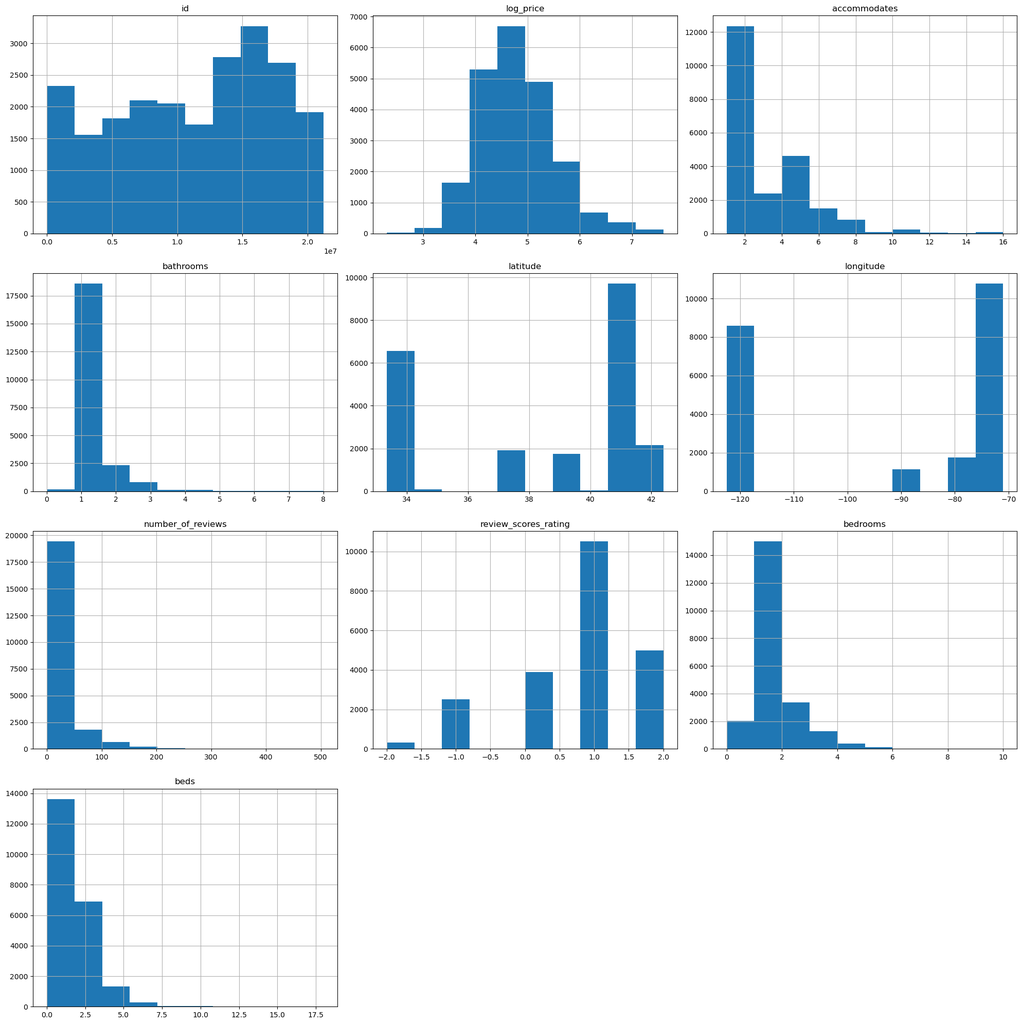

```python
import matplotlib.pyplot as plt
data.hist(figsize=(20,20))
plt.tight_layout()
plt.show()
```

On voit par exemple que le log_price varie environ de 3 à 7, et que la plupart des logements ont un log_price compris entre 4 et 6. On voit aussi ici que la variable id risque de ne rien nous indiquer, étant donné que la répartition ne semble suivre aucun schéma. Cela semble évident quand on sait que l'id ne contient aucune réelle caractéristique sur le logement en lui-même.

Pour mieux visualiser le prix, on va afficher l'histogramme plus détaillé

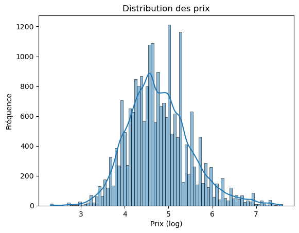

```python
import seaborn as sns #importation de la librairie
sns.histplot(data['log_price'], kde=True)
plt.title('Distribution des prix')
plt.xlabel('Prix (log)')
plt.ylabel('Fréquence')
plt.show()
```

On voit ici que le logarithme du prix se rapproche d'une gaussienne.

On va maitenant afficher la matrice de corrélation entre les différentes colonnes numériques du dataset, afin d'observer particulièrement l'influence de chaque variable sur log_price

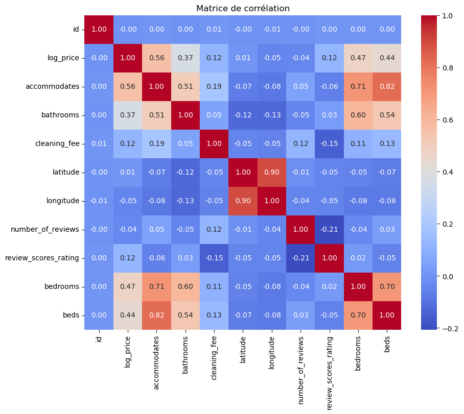

```python
correlation_matrix = data.corr()
plt.figure(figsize=(10, 8))
sns.heatmap(correlation_matrix, annot=True, cmap='coolwarm', fmt=".2f")
plt.title("Matrice de corrélation")
plt.show()
```

Plus une valeur est proche de 1 ou -1, plus elle influe sur la valeur de la variable correspondante. Par exemple, au croisement entre log_price et accomodates, on a la valeur 0.56 qui est une valeur positive relativement proche de 1. Cela signifie que plus accomadates augmente, plus log_price augmente (dans une certaine mesure, étant donné que le coefficient n'est pas égale à un). Si on a une valeur négative, la proportionnalité est inverse. On voit ici que les variables qui seront les plus intéressantes seront accomodates, bathroom, bedrooms et beds. On voit que la valeur de review_score_rating est seulement de 0.12, ce qui indique de notre manipulation réalisé précédemment n'a pas forcément beaucoup aidé à établir une relation entre le score et log_price

Même si son score de corrélation est assez faible, on va s'intéresser à la variable cleaning fee, qui est un booléen, et la traduire numériquement afin de pouvoir l'exploiter dans nos modèles

```python
data['cleaning_fee'] = data['cleaning_fee'].map({True: 1, False: 0})
```

```python
print(data['cleaning_fee'].corr(data['log_price']))
```

```
0.11511629440631772
```

On va maintenant s'intéresser aux variables de type objects, en essayant de voir si certaines pourraient être traduites numériquement, afin de trouver l'influence que chacun a sur la valeur de log_price

On va commencer avec property_type. Par l'intuition, on peut déjà supposer que son influence sur le prix du logement sera élevée, étant donné que le prix d'un logement varie beaucoup en fonction de si l'on loue une maison entière ou simplement une chambre.

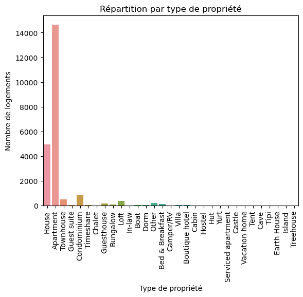

```python
#On commence par visualiser les différents types de propriétés et leur répartition sur un histogramme
sns.countplot(x='property_type', data=data)
plt.title('Répartition par type de propriété')
plt.xlabel('Type de propriété')
plt.ylabel('Nombre de logements')
plt.xticks(rotation=90) # permet de mieux voir le nom des diifférents batons
plt.show()
```

On constate que même si l'on dispose de plus de 30 types de propriétés différents, house et apartment représente une vaste majorité de nos données. Ainsi, on risque de ne pas pouvoir beaucoup expliquer les variations de pri en fonction de cette variable, étant donné la faible diversité de celle-ci. (Les appartements sont tellement nombreux par rapport au reste qu'il faudra expliquer la différence de prix entre les appartements entre eux, on ne pourra pas vraiment se servir du fait qu'ils sont de cette catégorie pour expliquer leur prix).

Vérifions cette théorie. On va regarder les moyennes de prix en fonction du type de propriété

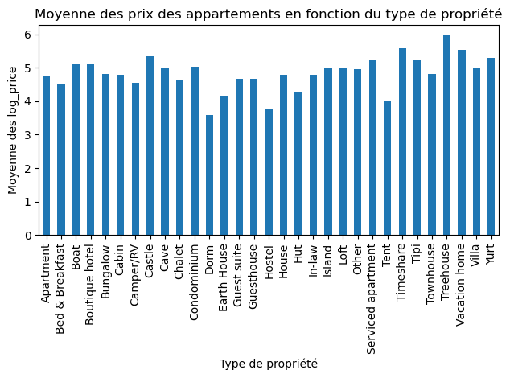

```python
mean_prices_by_property_type = data.groupby('property_type')['log_price'].mean()
mean_prices_by_property_type.plot(kind='bar')
plt.xlabel('Type de propriété')
plt.ylabel('Moyenne des log_price')
plt.title('Moyenne des prix des appartements en fonction du type de propriété')
plt.xticks(rotation=90)
plt.tight_layout()
plt.show()
```

On va créer des seuils respectant les tendances : on va considérer une moyenne de prix très faible si elle est sous 4, faible si elle est comprise entre 4 et 4.5, moyenne entre 4.5 et 4.9 et haute si elle est supérieure à 4.9 (ces choix ont été fait en réalisant plusieurs tests avec des seuils différents, et cette solution permet d'obtenir une des corrélations les plus fortes entre log_price et property_type.

```python
seuils = {'low': 4, 'medium': 4.5, 'high': 4.9}  # Définir les seuils
property_type_mapping = {}
for property_type, mean_log_price in mean_prices_by_property_type.items():
    if mean_log_price < seuils['low']:
        property_type_mapping[property_type] = -2
    elif seuils['low'] <= mean_log_price < seuils['medium']:
        property_type_mapping[property_type] = -1
    elif seuils['medium'] <= mean_log_price < seuils['high']:
        property_type_mapping[property_type] = 1
    else:
        property_type_mapping[property_type] = 2
data['property_type'] = data['property_type'].map(property_type_mapping)
print(data[['property_type', 'log_price']].tail())
```

```
       property_type  log_price
22229              1   4.605170
22230              1   5.043425
22231              1   5.220356
22232              1   5.273000
22233              2   4.852030
```

On voit ici que des valeurs du même type de propriété ont des prix très éloignés (4.6 et 5.2). Ce sont sans doute des appartements, qui, comme dit précédemment, représentent une grande partie de nos donées. Ainsi, la moyenne des log_price appartements est comprise entre 4.5 et 4.9, mais étant donnée la variance de nos observations, il est possible que ces données soient loin de la moyenne. Ainsi, cette colonne property_type servira surtout à expliquer le prix des données autres que les appartements, qui se détacheraient par une très forte (ou très faible) moyenne de prix avec peu de valeurs.

```python
print(data['property_type'].corr(data['log_price'])) # valeur de la corrélation entre notre nouvelle colonne numérique et log_price
```

```
0.12580159771845476
```

On va procéder au même traitement pour room_type, le type de chambre

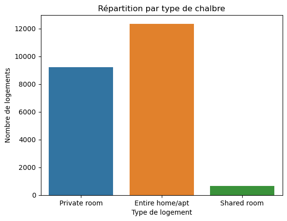

```python
sns.countplot(x='room_type', data=data)
plt.title('Répartition par type de chalbre')
plt.xlabel('Type de logement')
plt.ylabel('Nombre de logements')
plt.show()
```

On n'a que trois types de chambres différents, alors on devrait pouvoir mieux expliquer la corrélation entre cette donnée et log_price. Affichons les moyennes de log_price en fonction du type de chambre

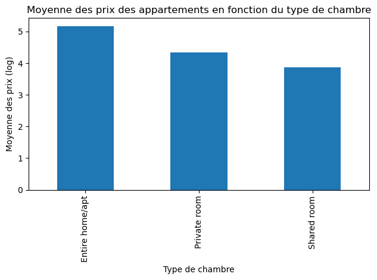

```python
mean_prices_by_room_type = data.groupby('room_type')['log_price'].mean()
mean_prices_by_room_type.plot(kind='bar')
plt.xlabel('Type de chambre')
plt.ylabel('Moyenne des prix (log)')
plt.title('Moyenne des prix des appartements en fonction du type de chambre')
plt.tight_layout()  # Ajustement automatique de la mise en page
plt.show()
```

On voit bien qu'une tendance se dessine, on va donc pouvoir remplacer ces valeurs par des valeurs numériques afin de les exploiter avec notre modèle par la suite

```python
room_type_mapping = {
    'Entire home/apt': 1,
    'Private room': 0,
    'Shared room': -1,
}
data['room_type'] = data['room_type'].map(room_type_mapping)
```

```python
print(data['room_type'].corr(data['log_price']))
```

```
0.6019973208773183
```

On obtient un coefficient de corrélation de 0.6 entre room_type et log_price, cette variable sera donc très utile pour notre prédiction.

On va maitenant aborder la colonne ammenities. Regardons tout d'abord les valeurs qu'elle prend

```python
print(data['amenities'][1])
```

```
{"Wireless Internet","Air conditioning",Kitchen,Heating,"Family/kid friendly","Smoke detector","Carbon monoxide detector","Fire extinguisher",Essentials,"Lock on bedroom door","24-hour check-in","Hair dryer",Iron,"translation missing: en.hosting_amenity_50","Self Check-In",Keypad,"Bed linens",Microw…
```

C'est donc une liste de différents équipements présents dans le logement. Récoltons la liste de tous les équipements disponibles

```python
amenities_lists = data['amenities'].str.strip('{}').str.replace('"', '').str.split(',')
all_amenities = []
for amenities_list in amenities_lists:
    all_amenities.extend(amenities_list)
unique_amenities = set(all_amenities)
print(unique_amenities)
```

```
{'', 'Lock on bedroom door', 'Bed linens', 'Wide clearance to shower & toilet', 'Roll-in shower with chair', 'Laptop friendly workspace', 'Essentials', '24-hour check-in', 'Handheld shower head', 'Children’s books and toys', 'Pocket wifi', 'Babysitter recommendations', 'Oven', 'Hangers', 'Pool', 'He…
```

On peut essayer de deviner quel équipement aura une influence sur le prix selon nous, par exemple la télé ou la connexion wifi, mais il sera plus simple de calculcer le coefficient de corrélation entre chaque équipement et le log_price, afin de ne pas en oublier. On va donc créer une colonne numérique pour chaque équipement : si le logement le possède, on mettre 1, 0 sinon.

```python
for equipment in unique_amenities:
    data[equipment] = data['amenities'].str.contains(equipment).astype(int)
data.head()
```

[output not shown]

[output cut: 38 more lines]

|  | id | log_price | property_type | room_type | amenities | accommodates | bathrooms | bed_type | cancellation_policy | cleaning_fee | ... | First aid kit | Refrigerator | Gym | BBQ grill | Washer | Smoking allowed | Baby bath | Keypad | Wide hallway clearance | Cleaning before checkout |
| --- | --- | --- | --- | --- | --- | --- | --- | --- | --- | --- | --- | --- | --- | --- | --- | --- | --- | --- | --- | --- | --- |
| 0 | 5708593 | 4.317488 | 1 | 0 | {TV,"Wireless Internet",Kitchen,"Free parking ... | 3 | 1.0 | Real Bed | flexible | 0 | ... | 0 | 0 | 0 | 0 | 1 | 0 | 0 | 0 | 0 | 0 |
| 1 | 14483613 | 4.007333 | 1 | 0 | {"Wireless Internet","Air conditioning",Kitche... | 4 | 2.0 | Real Bed | strict | 0 | ... | 0 | 1 | 0 | 0 | 0 | 0 | 0 | 1 | 0 | 0 |
| 2 | 10412649 | 7.090077 | 1 | 1 | {TV,"Wireless Internet","Air conditioning",Kit... | 6 | 2.0 | Real Bed | flexible | 0 | ... | 1 | 0 | 0 | 0 | 1 | 0 | 0 | 0 | 0 | 0 |
| 3 | 17954362 | 3.555348 | 1 | 0 | {TV,"Cable TV",Internet,"Wireless Internet","A... | 1 | 1.0 | Real Bed | flexible | 1 | ... | 0 | 1 | 0 | 1 | 0 | 0 | 0 | 1 | 0 | 0 |
| 4 | 9969781 | 5.480639 | 1 | 1 | {TV,"Cable TV",Internet,"Wireless Internet",Ki... | 4 | 1.0 | Real Bed | moderate | 1 | ... | 1 | 0 | 0 | 0 | 1 | 0 | 0 | 1 | 0 | 0 |

5 rows × 153 columns

On a donc maintenant plus de 150 colonnes. Pour savoir lesquelles garder, on va simplement regarder lesquels ont un coefficient de corrélation supérieur à 0.25 avec log_price, (on choisi 0.25 afin de réduire considérablement le nombre de colonnes)

```python
resultat = 'log_price'
donnees = {'Private living room', 'Baby monitor', 'Wireless Internet', 'Wide hallway clearance', 'Oven', 'Accessible-height bed', 'Cat(s)', 'Fire extinguisher', 'Garden or backyard', 'Firm mattress', 'Other pet(s)', 'Bed linens', 'Bathtub with shower chair', 'Dryer', 'Hair dryer', 'Hangers', 'Internet', 'Patio or balcony', ' smooth pathway to front door', 'Family/kid friendly', 'Wide clearance to shower & toilet', 'Cable TV', 'Private entrance', 'Free parking on street', 'Ski in/Ski out', 'Private bathroom', 'Breakfast', 'Long term stays allowed', 'Outlet covers', 'Fixed grab bars for shower & toilet', '24-hour check-in', 'Dishes and silverware', 'Luggage dropoff allowed', 'Shampoo', 'Indoor fireplace', 'Pack ’n Play/travel crib', 'Free parking on premises', 'Pocket wifi', 'Roll-in shower with chair', 'Refrigerator', 'Microwave', 'Washer', 'Lake access', 'Keypad', 'Doorman', 'Baby bath', 'Hot tub', 'Table corner guards', 'Grab-rails for shower and toilet', 'Other', 'Elevator', 'Air conditioning', 'Single level home', 'Cleaning before checkout', 'Smart lock', 'Extra pillows and blankets', 'Changing table', 'Smoking allowed', 'Smoke detector', 'Wheelchair accessible', 'Laptop friendly workspace', 'Ethernet connection', 'Babysitter recommendations', 'Accessible-height toilet', 'Wide entryway', 'Buzzer/wireless intercom', 'High chair', 'Hot water kettle', 'translation missing: en.hosting_amenity_49', 'Path to entrance lit at night', 'Paid parking off premises', 'Bathtub', 'Elevator in building', 'Game console', 'Cooking basics', 'Stair gates', 'translation missing: en.hosting_amenity_50', 'Ground floor access', 'Safety card', 'Crib', 'Hot water', 'Pool', 'Self Check-In', 'Children’s dinnerware', 'Step-free access', 'Lockbox', 'Children’s books and toys', 'Pets allowed', 'BBQ grill', 'Lock on bedroom door', 'Waterfront', 'Smartlock', 'Wide clearance to bed', 'Carbon monoxide detector', 'TV', 'Gym', 'Wide doorway', 'Iron', 'Stove', 'Disabled parking spot', 'Room-darkening shades', 'Kitchen', 'Handheld shower head', 'Essentials', 'Fireplace guards', 'First aid kit', 'Dishwasher', 'Window guards', 'Beach essentials', 'Suitable for events', 'EV charger', 'Firm matress', 'Dog(s)', 'Doorman Entry', 'Coffee maker', 'Washer / Dryer', 'Host greets you', 'Air purifier', 'Flat smooth pathway to front door', 'Beachfront', 'Heating', 'Pets live on this property', 'Flat', 'Well-lit path to entrance'}
correlations = {}
for colonne in donnees:
    correlation = data[colonne].corr(data[resultat])
    correlations[colonne] = correlation

correlation_df = pd.DataFrame.from_dict(correlations, orient='index', columns=['Correlation avec la colonne ' + resultat])

correlation_df_filtree = correlation_df[correlation_df['Correlation avec la colonne ' + resultat].abs() >= 0.25]
print(correlation_df_filtree)
```

```
                     Correlation avec la colonne log_price
Family/kid friendly                               0.290680
TV                                                0.274277
```

Les deux seules colonnes à garder sont donc TV et Family/kid friendly

```python
colonnes_a_supprimer = correlation_df[correlation_df['Correlation avec la colonne ' + resultat].abs() < 0.25].index
data = data.drop(colonnes_a_supprimer, axis=1)
```

```python
data.head()
```

|  | id | log_price | property_type | room_type | amenities | accommodates | bathrooms | bed_type | cancellation_policy | cleaning_fee | ... | review_scores_rating | zipcode | bedrooms | beds |  | Family/kid friendly | TV | Other pet(s) | Cat(s) | Dog(s) |
| --- | --- | --- | --- | --- | --- | --- | --- | --- | --- | --- | --- | --- | --- | --- | --- | --- | --- | --- | --- | --- | --- |
| 0 | 5708593 | 4.317488 | 1 | 0 | {TV,"Wireless Internet",Kitchen,"Free parking ... | 3 | 1.0 | Real Bed | flexible | 0 | ... | 2.0 | 90804 | 0.0 | 2.0 | 1 | 0 | 1 | 0 | 0 | 0 |
| 1 | 14483613 | 4.007333 | 1 | 0 | {"Wireless Internet","Air conditioning",Kitche... | 4 | 2.0 | Real Bed | strict | 0 | ... | -1.0 | 11385 | 1.0 | 2.0 | 1 | 1 | 0 | 0 | 0 | 0 |
| 2 | 10412649 | 7.090077 | 1 | 1 | {TV,"Wireless Internet","Air conditioning",Kit... | 6 | 2.0 | Real Bed | flexible | 0 | ... | 2.0 | 20009 | 2.0 | 2.0 | 1 | 1 | 1 | 0 | 0 | 0 |
| 3 | 17954362 | 3.555348 | 1 | 0 | {TV,"Cable TV",Internet,"Wireless Internet","A... | 1 | 1.0 | Real Bed | flexible | 1 | ... | 1.0 | 11104 | 1.0 | 1.0 | 1 | 1 | 1 | 0 | 0 | 0 |
| 4 | 9969781 | 5.480639 | 1 | 1 | {TV,"Cable TV",Internet,"Wireless Internet",Ki... | 4 | 1.0 | Real Bed | moderate | 1 | ... | 1.0 | 94131 | 2.0 | 2.0 | 1 | 1 | 1 | 0 | 0 | 0 |

5 rows × 34 columns

# Les colonnes cat(s) other pet(s) et dog(s) n'ont pas été supprimées malgré leur faible coefficient de corrélation, on va donc les supprimer manuellement

```python
data = data.drop({'Dog(s)','Cat(s)','Other pet(s)',''}, axis=1) #une colonne vide était aussi présente, on la retire également
```

```python
data.head() #vérification de la suppression des colonnes OK
```

|  | id | log_price | property_type | room_type | amenities | accommodates | bathrooms | bed_type | cancellation_policy | cleaning_fee | ... | longitude | name | neighbourhood | number_of_reviews | review_scores_rating | zipcode | bedrooms | beds | Family/kid friendly | TV |
| --- | --- | --- | --- | --- | --- | --- | --- | --- | --- | --- | --- | --- | --- | --- | --- | --- | --- | --- | --- | --- | --- |
| 0 | 5708593 | 4.317488 | 1 | 0 | {TV,"Wireless Internet",Kitchen,"Free parking ... | 3 | 1.0 | Real Bed | flexible | 0 | ... | -118.134410 | Island style Spa Studio | Long Beach | 0 | 2.0 | 90804 | 0.0 | 2.0 | 0 | 1 |
| 1 | 14483613 | 4.007333 | 1 | 0 | {"Wireless Internet","Air conditioning",Kitche... | 4 | 2.0 | Real Bed | strict | 0 | ... | -73.909439 | Beautiful and Simple Room W/2 Beds, 25 Mins to... | Ridgewood | 38 | -1.0 | 11385 | 1.0 | 2.0 | 1 | 0 |
| 2 | 10412649 | 7.090077 | 1 | 1 | {TV,"Wireless Internet","Air conditioning",Kit... | 6 | 2.0 | Real Bed | flexible | 0 | ... | -77.031651 | 2br/2ba luxury condo perfect for infant / toddler | U Street Corridor | 0 | 2.0 | 20009 | 2.0 | 2.0 | 1 | 1 |
| 3 | 17954362 | 3.555348 | 1 | 0 | {TV,"Cable TV",Internet,"Wireless Internet","A... | 1 | 1.0 | Real Bed | flexible | 1 | ... | -73.924248 | Manhattan view from Queens. Lovely single room . | Sunnyside | 19 | 1.0 | 11104 | 1.0 | 1.0 | 1 | 1 |
| 4 | 9969781 | 5.480639 | 1 | 1 | {TV,"Cable TV",Internet,"Wireless Internet",Ki... | 4 | 1.0 | Real Bed | moderate | 1 | ... | -122.430665 | Zen Captured Noe Valley House | Noe Valley | 15 | 1.0 | 94131 | 2.0 | 2.0 | 1 | 1 |

5 rows × 30 columns

On passe à la variable cancellation_policy.

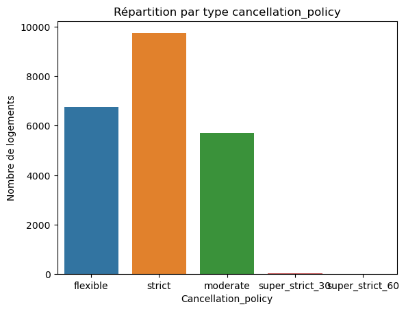

```python
sns.countplot(x='cancellation_policy', data=data)
plt.title('Répartition par type cancellation_policy')
plt.xlabel('Cancellation_policy')
plt.ylabel('Nombre de logements')
plt.show()
```

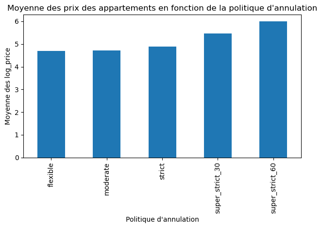

```python
mean_prices_by_policy = data.groupby('cancellation_policy')['log_price'].mean()
mean_prices_by_policy.plot(kind='bar')
plt.xlabel('Politique d\'annulation')
plt.ylabel('Moyenne des log_price')
plt.title('Moyenne des prix des appartements en fonction de la politique d\'annulation')
plt.tight_layout()
plt.show()
```

On va regrouper flexible et moderate ensemble, et créer une catégorie numérique pour chaque palier au dessus, étant donné que l'écart augmente plus considérablement.

```python
cancellation_policy_mapping = {
    'flexible': 0,
    'moderate': 0,
    'strict': 2,
    'super_strict_30':5,
    'super_strict_60': 10
}
data['cancellation_policy'] = data['cancellation_policy'].map(cancellation_policy_mapping)
```

```python
print(data['cancellation_policy'].corr(data['log_price']))
```

```
0.13515090086727913
```

Ce score est relativement peu élévé, étant donné le peu de données représentant les catégories super strictes qui sont celles qui varient vraiment du reste.

On passe au type de lit :

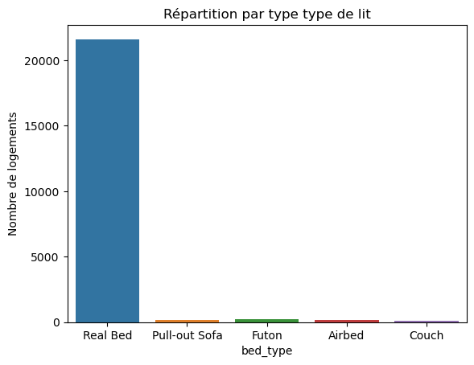

```python
sns.countplot(x='bed_type', data=data)
plt.title('Répartition par type type de lit')
plt.xlabel('bed_type')
plt.ylabel('Nombre de logements')
plt.show()
```

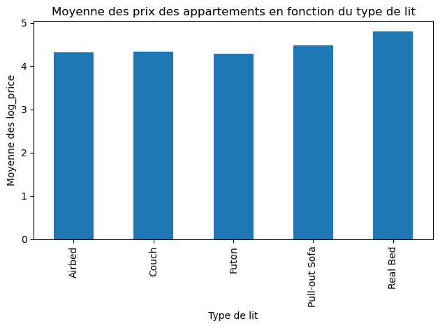

```python
mean_prices_by_bed_type = data.groupby('bed_type')['log_price'].mean()
mean_prices_by_bed_type.plot(kind='bar')
plt.xlabel('Type de lit')
plt.ylabel('Moyenne des log_price')
plt.title('Moyenne des prix des appartements en fonction du type de lit')
plt.tight_layout()
plt.show()
```

On voit que la quasi totalité des lit sont des "real bed" et que tous les autres types de lit sont dans des logements légèrement moins chers que la moyenne des real bed. On va donc mettre 1 pour real bed et 0 pour les autres, même si au vu de la répartition des différents types, cette variable risque de ne pas expliquer beaucoup.

```python
bed_type_mapping = {
    'Real Bed': 1,
    'Pull-out Sofa': 0,
    'Futon': 0,
    'Airbed':0,
    'Couch': 0
}
data['bed_type'] = data['bed_type'].map(bed_type_mapping)
```

```python
print(data['bed_type'].corr(data['log_price']))
```

```
0.10237866110095922
```

A nouveau, la valeur est plutôt faible pour une corrélation, pour la même raison que cancellation_policy

Etude de la variable city

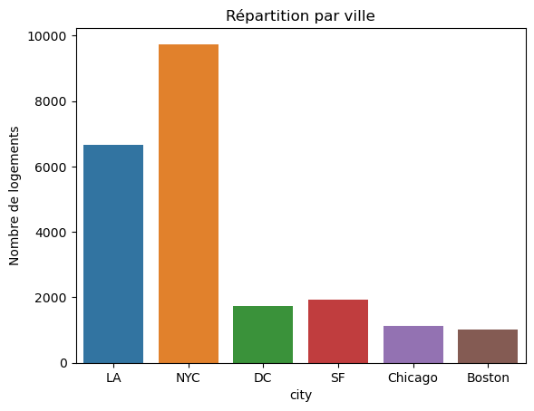

```python
sns.countplot(x='city', data=data)
plt.title('Répartition par ville')
plt.xlabel('city')
plt.ylabel('Nombre de logements')
plt.show()
```

On est réparti dans 6 villes différentes, visualisons ces données et leurs prix

On commence par le diagramme en violon

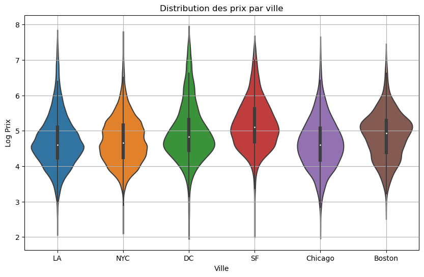

```python
plt.figure(figsize=(10, 6))
sns.violinplot(x='city', y='log_price', data=data)
plt.title('Distribution des prix par ville')
plt.xlabel('Ville')
plt.ylabel('Log Prix')
plt.grid(True)
plt.show()
```

Le point blanc dans chaque forme représente la valeur médiane, et la largeur de la forme représente la largeur du graphique densité = fréquence : plus la forme est large, plus le nombre de données présentes à cette valeur de prix est grand. On peut conclure de ce graphique que la répartition des prix dans chaque ville est relativement uniforme.

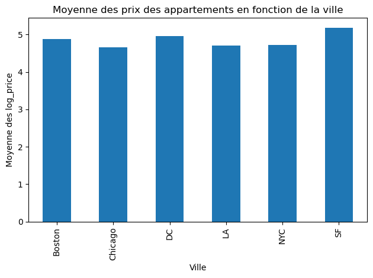

```python
mean_prices_by_bed_type = data.groupby('city')['log_price'].mean()
mean_prices_by_bed_type.plot(kind='bar')
plt.xlabel('Ville')
plt.ylabel('Moyenne des log_price')
plt.title('Moyenne des prix des appartements en fonction de la ville')
plt.tight_layout()
plt.show()
```

On voit que Boston et DC sont quasiment au même niveau, de même pour Chicago LA et NYC, et que SF est plus haut. On va donc numériser la colonne avec la map suivante :

```python
city_mapping = {
    'LA': -1,
    'NYC': -1,
    'DC': 0,
    'SF':1,
    'Boston':0,
    'Chicago': -1
}
data['city_numerique'] = data['city'].map(city_mapping)
```

```python
print(data['city_numerique'].corr(data['log_price']))
```

```
0.19837161137383966
```

On obtient un coefficient de corrélation proche de 0.2, ce qui est relativement exploitable.

Pour host_has_profile_pic et host_identifty_verified, en remplaçant t par 1 et f par 0, on trouve une corrélation quasi nulle avec le prix, on ne va donc pas s'attarder sur ces colonnes

Regardons pour last_review et first_review, qui ont toutes deux plus d'un cinquième de NaN (maitenant non spécifié)

```python
log_price_non_specifie = data[data['first_review'] == 'non spécifié']['log_price']
log_price_specifie = data[data['first_review'] != 'non spécifié']['log_price']
mean_log_price_non_specifie = log_price_non_specifie.mean()
mean_log_price_specifie = log_price_specifie.mean()

print(mean_log_price_non_specifie)
print(mean_log_price_specifie)
```

```
4.916583717214111
4.747561631055757
```

On voit que le fait de spécifier la date de la première revue ne permet pas d'augmenter le prix, si ce n'est l'inverse. Etant donné que la différence de prix est assez faible, on ne va pas prendre en compte cette donnée

```python
log_price_non_specifie = data[data['last_review'] == 'non spécifié']['log_price']
log_price_specifie = data[data['last_review'] != 'non spécifié']['log_price']
mean_log_price_non_specifie = log_price_non_specifie.mean()
mean_log_price_specifie = log_price_specifie.mean()

print(mean_log_price_non_specifie)
print(mean_log_price_specifie)
```

```
4.916456735832598
4.747682651889793
```

Idem pour last_review

Pour les reviews, on a de toute façon déjà la colonne review_score_rating traitée précedemment qui prend en compte les évaluations. On ne va donc pas non plus prendre en compte number_of_reviews, d'autant plus que la plupart des logements en ont le même nombre (cf histogramme au début du notebook)

On va regarder pour la colonne instant_bookable. Instinctivement, on peut penser que cette colonne va influer sur le prix

```python
data['instant_bookable'] = data['instant_bookable'].replace({'f':0, 't': 1}).astype('int64')
```

```python
print(data['instant_bookable'].corr(data['log_price']))
```

```
-0.04048238798900665
```

Cette donnée doit être trop aléatoire pour prédire quoi que ce soit : un hôte peut très bien décider de ne pas cocher cette option, peu importe le prix de son logement. Cette donnée ne sera donc pas utile à l'analyse.

Colonne host_since : on va voir si le nombre d'années que l'hote a passé sur la plateforme influe sur le prix de son logement

```python
from datetime import datetime
data['host_since'] = pd.to_datetime(data['host_since'], errors='coerce')
date_actuelle = datetime.now()
data['years_since_hosting'] = (date_actuelle - data['host_since']).dt.days / 365
data.loc[data['years_since_hosting'] < 0, 'years_since_hosting'] = 0
data['years_since_hosting'].fillna(0, inplace=True)
data[['host_since', 'years_since_hosting']].head()
```

|  | host_since | years_since_hosting |
| --- | --- | --- |
| 0 | 2015-12-12 | 8.457534 |
| 1 | 2016-11-04 | 7.558904 |
| 2 | 2016-12-11 | 7.457534 |
| 3 | 2012-08-04 | 11.813699 |
| 4 | 2013-07-25 | 10.841096 |

```python
print(data['years_since_hosting'].corr(data['log_price']))
```

```
0.07075658184745563
```

Le coefficient est très faible, l'ancienneté de l'hote ne joue pas sur le prix de son logement

Constatons les différents coefficients de corrélations entre nos colonnes et log_price

```python
colonnes_numeriques = data.select_dtypes(include=['float64', 'int64','int32']).columns
correlations = {}
for colonne in colonnes_numeriques:
    correlation = data[colonne].corr(data['log_price'])
    correlations[colonne] = correlation
correlation_df = pd.DataFrame.from_dict(correlations, orient='index', columns=['Corrélation avec log_price'])
print(correlation_df)
```

```
                      Corrélation avec log_price
id                                     -0.002122
log_price                               1.000000
property_type                           0.125802
room_type                               0.601997
accommodates                            0.564874
bathrooms                               0.367718
bed_type                                0.102379
cancellation_policy                     0.135151
cleaning_fee                            0.115116
instant_bookable                       -0.040482
latitude                                0.005231
longitude                              -0.045348
number_of_reviews                      -0.039138
review_scores_rating                    0.120884
bedrooms                                0.472728
beds                                    0.435068
Family/kid friendly                     0.290680
TV                                      0.274277
city_numerique                          0.198372
years_since_hosting                     0.070757
```

```python
data.info()
```

```
<class 'pandas.core.frame.DataFrame'>
RangeIndex: 22234 entries, 0 to 22233
Data columns (total 32 columns):
 #   Column                  Non-Null Count  Dtype
---  ------                  --------------  -----
 0   id                      22234 non-null  int64
 1   log_price               22234 non-null  float64
 2   property_type           22234 non-null  int64
 3   room_type               22234 non-null  int64
 4   amenities               22234 non-null  object
 5   accommodates            22234 non-null  int64
 6   bathrooms               22234 non-null  float64
 7   bed_type                22234 non-null  int64
 8   cancellation_policy     22234 non-null  int64
 9   cleaning_fee            22234 non-null  int64
```

[output cut: 24 more lines]

id n'est pas utilisable

Que faire avec la colonne description ?

```python
print(data['description'].iloc[0])
```

```
Large bright airy room with 2 balconies and Jacuzzi tub converted to a soaking tub. Laundry, new mini frig and microwave. All new linens. Awesome Mexican food and Sushi walking distance across street. Free bikes. Golf course across street. Driveway parking for up to 3 cars. We are working on a new d…
```

Il semblerait que la colonne amenities soit une traduction de la description. Cette colonne serait trop compliquée à analyser, et le résultat risquerait de ne pas être vraiment fiable. On va donc la laisser de côté.

Host response rate :

```python
log_price_non_specifie = data[data['host_response_rate'] == 'non spécifié']['log_price']
log_price_specifie = data[data['host_response_rate'] != 'non spécifié']['log_price']
mean_log_price_non_specifie = log_price_non_specifie.mean()
mean_log_price_specifie = log_price_specifie.mean()

print(mean_log_price_non_specifie)
print(mean_log_price_specifie)
```

```
4.840640347661255
4.764807492007066
```

La différence entre non spécifié et spécifié est très faible, et on compte énormémement de non spécifié, on va donc ne pas utiliser cette donnée

```python
from geopy.distance import geodesic
# Coordonnées des centres des villes
city_centers = {
    'Boston': (42.3601, -71.0589),
    'NYC': (40.7128, -74.0060),
    'SF': (37.7749, -122.4194),
    'Chicago': (41.8781, -87.6298),
    'LA': (34.0522, -118.2437),
    'DC': (38.9072, -77.0369),
}
# Fonction pour calculer la distance par rapport au centre de la ville
def calculate_distance(row):
    city = row['city']
    if city in city_centers:
        city_center = city_centers[city]
        apartment_location = (row['latitude'], row['longitude'])
        return geodesic(city_center, apartment_location).kilometers
    else:
        return None
data['distance_to_city_center'] = data.apply(calculate_distance, axis=1)
data[['city', 'latitude', 'longitude', 'distance_to_city_center']].head()
```

|  | city | latitude | longitude | distance_to_city_center |
| --- | --- | --- | --- | --- |
| 0 | LA | 33.782712 | -118.134410 | 31.554175 |
| 1 | NYC | 40.705468 | -73.909439 | 8.200298 |
| 2 | DC | 38.917537 | -77.031651 | 1.234504 |
| 3 | NYC | 40.736001 | -73.924248 | 7.371738 |
| 4 | SF | 37.744896 | -122.430665 | 3.475009 |

```python
stats = data.groupby('city')['distance_to_city_center'].agg(['mean', 'var'])
print(stats)
```

```
              mean         var
city
Boston    4.101084    8.422592
Chicago   6.889271   16.132681
DC        3.263273    3.940670
LA       17.132821  111.978222
NYC       7.222086   19.327693
SF        3.135522    3.413735
```

```python
print(data['distance_to_city_center'].corr(data['log_price']))
```

```
-0.13377486758954607
```

On voit ici que la distance au centre ville n'est pas vraiment représentative du prix du logement. Il serait intéressant de se demander si on remarque une différence de corrélation en applicant un critère sur le fait que le logement soit dans le centre même de la ville, car cela pourrait être plus cohérent : si un logement est situé à plusieurs kilomètres du centre, que ce soit 15 ou 20, il faudra de toute façon prendre un véhicule pour le rejoindre, tandis que s'il en est très proche, l'aspect pratique se révèle.

```python
mean_distances = data.groupby('city')['distance_to_city_center'].mean().to_dict()
def replace_distance(row):
    city = row['city']
    if row['distance_to_city_center'] < 5:
        return 1
    else:
        return 0

data['distance_to_city_center'] = data.apply(replace_distance, axis=1)
```

```python
print(data['distance_to_city_center'].corr(data['log_price']))
```

```
0.25750984032545987
```

Après avoir testé plusieurs valeurs, on voit que c'est la distance 5 kilomètres qui semble la plus pertinente pour trouver une corrélation avec le log_price.

Bien que cette variable s'appelle 'distance_to_city_center', elle représente plus le fait qu'un logement soit proche de l'hypercentre de la ville que sa distance réelle avec celui-ci

## Modèles et prédiction

Pour rappel, voici les colonnes numériques et leur coefficient de corrélation avec le log price que nous allons pouvoir exploiter :

```python
colonnes_numeriques = data.select_dtypes(include=['float64', 'int64','int32']).columns

correlations = {}

for colonne in colonnes_numeriques:
    correlation = data[colonne].corr(data['log_price'])
    correlations[colonne] = correlation

correlation_df = pd.DataFrame.from_dict(correlations, orient='index', columns=['Corrélation avec log_price'])
print(correlation_df)
```

```
                         Corrélation avec log_price
id                                        -0.002122
log_price                                  1.000000
property_type                              0.125802
room_type                                  0.601997
accommodates                               0.564874
bathrooms                                  0.367718
bed_type                                   0.102379
cancellation_policy                        0.135151
cleaning_fee                               0.115116
instant_bookable                          -0.040482
latitude                                   0.005231
longitude                                 -0.045348
number_of_reviews                         -0.039138
review_scores_rating                       0.120884
bedrooms                                   0.472728
beds                                       0.435068
Family/kid friendly                        0.290680
TV                                         0.274277
city_numerique                             0.198372
years_since_hosting                        0.070757
distance_to_city_center                    0.257510
```

Latitude et longitude ne seront pas exploitées, car elles sont représentées dans distance_to_city_center.

#### Notez que pour définir l'efficacité d'un modèle, on va calculer son score R2 et son MSE en entrainement et en test.

Commençons par essayer d'appliquer une regression linéaire simple, en donnant toutes les colonnes numériques exploitables.

```python
#Importation des différentes librairies
from sklearn.model_selection import train_test_split
from sklearn.linear_model import LinearRegression
from sklearn.metrics import mean_squared_error, r2_score
```

```python
#séparation du dataset en deux dataset : un avec les variables explicatives et l'autre avec la variable à expliquer
X = data[['property_type','room_type','accommodates','bathrooms','bed_type','cancellation_policy','cleaning_fee','instant_bookable','number_of_reviews','review_scores_rating','bedrooms','beds','TV','Family/kid friendly','city_numerique','years_since_hosting','distance_to_city_center']]
y = data['log_price']
```

```python
X_train, X_test, y_train, y_test = train_test_split(X, y)
modele_rl_1 = LinearRegression()
modele_rl_1.fit(X_train, y_train)
y_pred_train = modele_rl_1.predict(X_train)
y_pred_test = modele_rl_1.predict(X_test)
print(f"Score en entrainenement : {r2_score(y_true=y_train, y_pred=y_pred_train)}")
print(f"Score en test : {r2_score(y_true=y_test, y_pred=y_pred_test)}")
mse_train = mean_squared_error(y_train, y_pred_train)
mse_test = mean_squared_error(y_test, y_pred_test)
print(f'MSE pour l\'ensemble d\'entraînement: {mse_train}')
print(f'MSE pour l\'ensemble de test: {mse_test}')
```

```
Score en entrainenement : 0.5827864312036664
Score en test : 0.5685259143408378
MSE pour l'ensemble d'entraînement: 0.21536577059830456
MSE pour l'ensemble de test: 0.2233944004661363
```

```
                    Feature  Coefficient
1                 room_type     0.520648
16  distance_to_city_center     0.252451
3                 bathrooms     0.148009
10                 bedrooms     0.131726
0             property_type     0.128064
12                       TV     0.123443
9      review_scores_rating     0.089168
2              accommodates     0.080185
14           city_numerique     0.075317
6              cleaning_fee    -0.052050
7          instant_bookable    -0.041834
11                     beds    -0.039332
13      Family/kid friendly     0.035804
4                  bed_type     0.027764
5       cancellation_policy     0.016040
15      years_since_hosting     0.012481
8         number_of_reviews    -0.000732
```

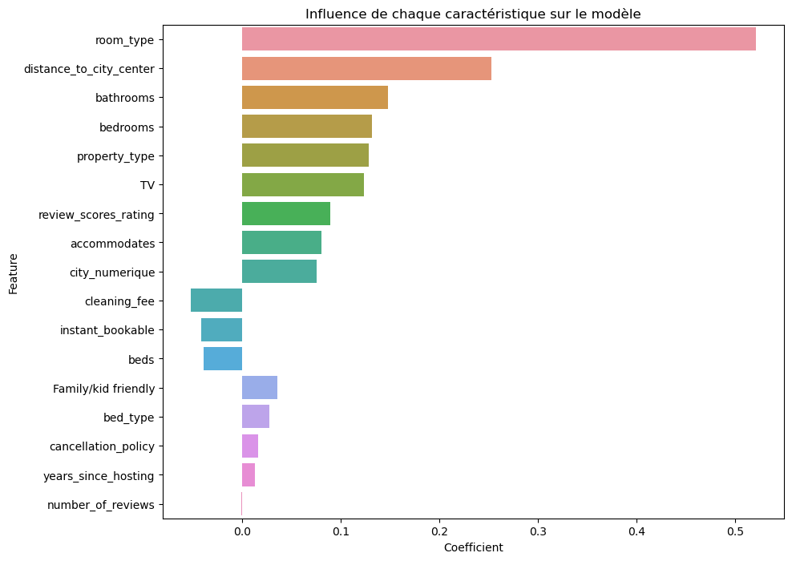

```python
coefficients = modele_rl_1.coef_
features = X.columns

# Créer un DataFrame pour afficher les coefficients
coef_df = pd.DataFrame({'Feature': features, 'Coefficient': coefficients})

# Trier le DataFrame par valeur absolue des coefficients pour mieux visualiser l'importance
coef_df['Absolute Coefficient'] = coef_df['Coefficient'].abs()
coef_df = coef_df.sort_values(by='Absolute Coefficient', ascending=False)

print(coef_df[['Feature', 'Coefficient']])
import matplotlib.pyplot as plt
import seaborn as sns
plt.figure(figsize=(10, 8))
sns.barplot(x='Coefficient', y='Feature', data=coef_df)
plt.title('Influence de chaque caractéristique sur le modèle')
plt.show()
```

On va tester de retirer les coeffs les plus faibles : number of review, years since host et cancellation policy

```python
X = data[['property_type','room_type','accommodates','bathrooms','bed_type','cleaning_fee','instant_bookable','review_scores_rating','bedrooms','beds','TV','Family/kid friendly','city_numerique','distance_to_city_center']]
X_train, X_test, y_train, y_test = train_test_split(X, y)
modele_rl_1 = LinearRegression()
modele_rl_1.fit(X_train, y_train)
y_pred_train = modele_rl_1.predict(X_train)
y_pred_test = modele_rl_1.predict(X_test)
print(f"Score en entrainenement : {r2_score(y_true=y_train, y_pred=y_pred_train)}")
print(f"Score en test : {r2_score(y_true=y_test, y_pred=y_pred_test)}")
mse_train = mean_squared_error(y_train, y_pred_train)
mse_test = mean_squared_error(y_test, y_pred_test)
print(f'MSE pour l\'ensemble d\'entraînement: {mse_train}')
print(f'MSE pour l\'ensemble de test: {mse_test}')
```

```
Score en entrainenement : 0.5792990012110044
Score en test : 0.5676126006455504
MSE pour l'ensemble d'entraînement: 0.21763624201062748
MSE pour l'ensemble de test: 0.22211872193323567
```

```
                    Feature  Coefficient
1                 room_type     0.530851
13  distance_to_city_center     0.255974
8                  bedrooms     0.142129
3                 bathrooms     0.141074
0             property_type     0.132308
10                       TV     0.127234
7      review_scores_rating     0.091676
2              accommodates     0.082391
12           city_numerique     0.067866
6          instant_bookable    -0.049599
5              cleaning_fee    -0.047518
9                      beds    -0.041055
11      Family/kid friendly     0.025748
4                  bed_type     0.015551
```

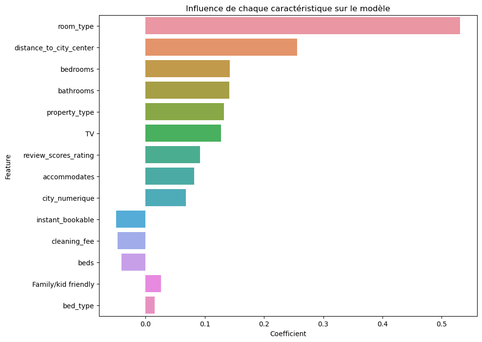

```python
coefficients = modele_rl_1.coef_
features = X.columns

# Créer un DataFrame pour afficher les coefficients
coef_df = pd.DataFrame({'Feature': features, 'Coefficient': coefficients})

# Trier le DataFrame par valeur absolue des coefficients pour mieux visualiser l'importance
coef_df['Absolute Coefficient'] = coef_df['Coefficient'].abs()
coef_df = coef_df.sort_values(by='Absolute Coefficient', ascending=False)

print(coef_df[['Feature', 'Coefficient']])

plt.figure(figsize=(10, 8))
sns.barplot(x='Coefficient', y='Feature', data=coef_df)
plt.title('Influence de chaque caractéristique sur le modèle')
plt.show()
```

Avec une régression linéaire classique sans modifier les données, on obtient un score R2 environ égal à 0.58. On va tester d'autre modèle sans modifier les données, pour comparer.

Régression linéaire SVR

```python
from sklearn.svm import LinearSVR
X_train, X_test, y_train, y_test = train_test_split(X, y)
modele_rl_2 = LinearSVR()
modele_rl_2.fit(X_train, y_train)
y_pred_train = modele_rl_2.predict(X_train)
y_pred_test = modele_rl_2.predict(X_test)
print(f"Score en entrainenement : {r2_score(y_true=y_train, y_pred=y_pred_train)}")
print(f"Score en test : {r2_score(y_true=y_test, y_pred=y_pred_test)}")
mse_train = mean_squared_error(y_train, y_pred_train)
mse_test = mean_squared_error(y_test, y_pred_test)
print(f'MSE pour l\'ensemble d\'entraînement: {mse_train}')
print(f'MSE pour l\'ensemble de test: {mse_test}')
```

```
Score en entrainenement : 0.5753494055517605
Score en test : 0.5665350059757334
MSE pour l'ensemble d'entraînement: 0.22033628064478858
MSE pour l'ensemble de test: 0.220892849007292
```

Ici, à chaque execution, on a des valeurs de r2 très différentes voire incohérentes (négatives). Cela peut s'expliquer par le fait que nos données ne sont pas normalisées. On pourra juger de l'efficacité de ce modèle après avoir utilisé la PCA par exemple.

Essayons une régression polynomiale de degré 2

```python
from sklearn.preprocessing import PolynomialFeatures
X_train, X_test, y_train, y_test = train_test_split(X, y)
poly = PolynomialFeatures(degree=2, include_bias=False)
X_poly_train = poly.fit_transform(X_train)
X_poly_test = poly.transform(X_test)
regressor = LinearRegression()
regressor.fit(X_poly_train, y_train)
y_pred_train = regressor.predict(X_poly_train)
y_pred_test = regressor.predict(X_poly_test)
r2_train = r2_score(y_train, y_pred_train)
r2_test = r2_score(y_test, y_pred_test)
print(f'R2 score for training set: {r2_train}')
print(f'R2 score for test set: {r2_test}')
mse_train = mean_squared_error(y_train, y_pred_train)
mse_test = mean_squared_error(y_test, y_pred_test)
print(f'MSE pour l\'ensemble d\'entraînement: {mse_train}')
print(f'MSE pour l\'ensemble de test: {mse_test}')
```

```
R2 score for training set: 0.6065328534173342
R2 score for test set: 0.6081009076904607
MSE pour l'ensemble d'entraînement: 0.20180960448060747
MSE pour l'ensemble de test: 0.20677673958291454
```

On obtient un score d'environ 0.6, ce qui est plutôt bien. On va essayer de faire mieux

Random Forest (arbre de décision)

```python
from sklearn.ensemble import RandomForestRegressor
X_train, X_test, y_train, y_test = train_test_split(X, y)
modele_rf = RandomForestRegressor(random_state=2)
modele_rf.fit(X_train, y_train)

# Faire des prédictions sur l'ensemble d'entraînement et de test
y_pred_train = modele_rf.predict(X_train)
y_pred_test = modele_rf.predict(X_test)

# Calculer le score R² en entraînement et en test
r2_train = r2_score(y_train, y_pred_train)
r2_test = r2_score(y_test, y_pred_test)

# Afficher les scores R²
print(f"Score R² en entraînement : {r2_train}")
print(f"Score R² en test : {r2_test}")
mse_train = mean_squared_error(y_train, y_pred_train)
mse_test = mean_squared_error(y_test, y_pred_test)
print(f'MSE pour l\'ensemble d\'entraînement: {mse_train}')
print(f'MSE pour l\'ensemble de test: {mse_test}')
```

```
Score R² en entraînement : 0.7899581768166615
Score R² en test : 0.5510169953969539
MSE pour l'ensemble d'entraînement: 0.10649049860875585
MSE pour l'ensemble de test: 0.24482120897070284
```

Ici, notre score est bien meilleur en entraînement qu'en test, ce qui signifie que le modèle sur apprend

Test avec le gradient boosting. Ce modèle est souvent utilisé dans des problèmes de régression.

```python
from sklearn.ensemble import GradientBoostingRegressor
X_train, X_test, y_train, y_test = train_test_split(X, y,random_state=2)
modele_final = GradientBoostingRegressor(random_state=2)
modele_final.fit(X_train, y_train)
y_pred_train = modele_final.predict(X_train)
y_pred_test = modele_final.predict(X_test)
r2_train = r2_score(y_train, y_pred_train)
r2_test = r2_score(y_test, y_pred_test)
print(f'R2 score for training set: {r2_train}')
print(f'R2 score for test set: {r2_test}')
mse_train = mean_squared_error(y_train, y_pred_train)
mse_test = mean_squared_error(y_test, y_pred_test)
print(f'MSE pour l\'ensemble d\'entraînement: {mse_train}')
print(f'MSE pour l\'ensemble de test: {mse_test}')
```

```
R2 score for training set: 0.612921550604974
R2 score for test set: 0.6212601156880513
MSE pour l'ensemble d'entraînement: 0.19781400588193113
MSE pour l'ensemble de test: 0.20192737843285086
```

### C'est ce modèle qui nous apporte le meilleur score R2 en ayant un MSE similaire aux autres, c'est donc celui-ci qu'on va garder.

Notez que le random state a été déterminé de manière empirique, 2 étant la valeur qui fournissait les meilleurs résultats observés.

Test avec le XGboost

```python
import xgboost as xgb
```

```python
X_train, X_test, y_train, y_test = train_test_split(X, y, test_size=0.2, random_state=2)

# Initialiser et entraîner le modèle XGBoost
xg_reg = xgb.XGBRegressor()
xg_reg.fit(X_train, y_train)

# Faire des prédictions sur l'ensemble d'entraînement et de test
y_pred_train = xg_reg.predict(X_train)
y_pred_test = xg_reg.predict(X_test)

# Calculer les scores R² en entraînement et en test
r2_train = r2_score(y_train, y_pred_train)
r2_test = r2_score(y_test, y_pred_test)

print(f'R2 score for training set: {r2_train}')
print(f'R2 score for test set: {r2_test}')
mse_train = mean_squared_error(y_train, y_pred_train)
mse_test = mean_squared_error(y_test, y_pred_test)
print(f'MSE pour l\'ensemble d\'entraînement: {mse_train}')
print(f'MSE pour l\'ensemble de test: {mse_test}')
```

```
R2 score for training set: 0.6883791646164868
R2 score for test set: 0.6108335069249203
MSE pour l'ensemble d'entraînement: 0.1596076257678712
MSE pour l'ensemble de test: 0.20789150231831832
```

#### On va maitenant essayer ces modèles après avoir prétraité les données, et pour cela on va utiliser l'analyse en composantes principales (PCA) (en reprenant le dataset à 17 colonnes)

```python
from sklearn.decomposition import PCA
from sklearn.preprocessing import StandardScaler
from numpy.linalg import eig,svd
X = data[['property_type','room_type','accommodates','bathrooms','bed_type','cancellation_policy','cleaning_fee','instant_bookable','number_of_reviews','review_scores_rating','bedrooms','beds','TV','Family/kid friendly','city_numerique','years_since_hosting','distance_to_city_center']]
scaler = StandardScaler()
X_std = scaler.fit_transform(X) #on standardise les données
```

On va essayer d'appliquer la méthode du coude sur le scree plot pour essayer de déterminer le nombre de composantes principales à utiliser

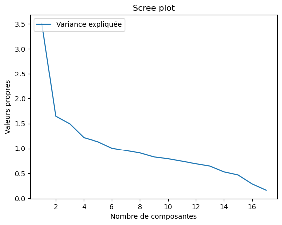

```python
pca = PCA().fit(X_std)
plt.plot(
    range(1,len(pca.explained_variance_ )+1),
    pca.explained_variance_,
    label='Variance expliquée')
plt.legend(loc='upper left')
plt.xlabel('Nombre de composantes')
plt.ylabel('Valeurs propres')
plt.title('Scree plot')
plt.show()
```

On voit que le coude est présent après 2 composantes principales, on va donc appliquer la PCA avec deux composantes principales

```python
pca = PCA(n_components=2)
pca.fit(X_std)
```

```
PCA(n_components=2)
```

```python
X_pca = pca.transform(X_std)
```

On teste les modèles avec le nouveau dataset post PCA

```python
X_train, X_test, y_train, y_test = train_test_split(X_pca, y)
modele_rl_1 = LinearRegression()
modele_rl_1.fit(X_train, y_train)
y_pred_train = modele_rl_1.predict(X_train)
y_pred_test = modele_rl_1.predict(X_test)
print(f"Score en entrainenement : {r2_score(y_true=y_train, y_pred=y_pred_train)}")
print(f"Score en test : {r2_score(y_true=y_test, y_pred=y_pred_test)}")
mse_train = mean_squared_error(y_train, y_pred_train)
mse_test = mean_squared_error(y_test, y_pred_test)
print(f'MSE pour l\'ensemble d\'entraînement: {mse_train}')
print(f'MSE pour l\'ensemble de test: {mse_test}')
```

```
Score en entrainenement : 0.3938802297330759
Score en test : 0.3993863472055065
MSE pour l'ensemble d'entraînement: 0.3097146734345527
MSE pour l'ensemble de test: 0.3203426993454897
```

On voit que le score est beaucoup moins bon. Vérifions la variance expliquée par chaque composante principiale

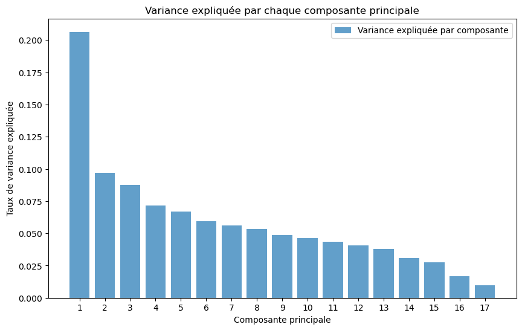

```python
pca = PCA().fit(X_std) #on ne précise pas le nombrbe de composantes principales pour visualiser la variance expliquée de chacune
pca.fit(X_std)
explained_variance_ratio = pca.explained_variance_ratio_
plt.figure(figsize=(10, 6))
components = np.arange(1, len(explained_variance_ratio) + 1)
plt.bar(components, explained_variance_ratio, alpha=0.7, align='center', label='Variance expliquée par composante')
plt.xlabel('Composante principale')
plt.ylabel('Taux de variance expliquée')
plt.title('Variance expliquée par chaque composante principale')
plt.xticks(components)
plt.legend()
plt.show()
```

```python
pca = PCA(n_components=17)
pca.fit(X_std)
X_pca = pca.transform(X_std)
```

```python
X_train, X_test, y_train, y_test = train_test_split(X_pca, y)
modele_rl_1 = LinearRegression()
modele_rl_1.fit(X_train, y_train)
y_pred_train = modele_rl_1.predict(X_train)
y_pred_test = modele_rl_1.predict(X_test)
print(f"Score en entrainenement : {r2_score(y_true=y_train, y_pred=y_pred_train)}")
print(f"Score en test : {r2_score(y_true=y_test, y_pred=y_pred_test)}")
mse_train = mean_squared_error(y_train, y_pred_train)
mse_test = mean_squared_error(y_test, y_pred_test)
print(f'MSE pour l\'ensemble d\'entraînement: {mse_train}')
print(f'MSE pour l\'ensemble de test: {mse_test}')
```

```
Score en entrainenement : 0.5800631938973819
Score en test : 0.57667739054752
MSE pour l'ensemble d'entraînement: 0.21720818256181468
MSE pour l'ensemble de test: 0.21785436824908994
```

Réessayons avec la RL svr :

```python
X_train, X_test, y_train, y_test = train_test_split(X_pca, y)
modele_rl_2 = LinearSVR()
modele_rl_2.fit(X_train, y_train)
y_pred_train = modele_rl_2.predict(X_train)
y_pred_test = modele_rl_2.predict(X_test)
print(f"Score en entrainenement : {r2_score(y_true=y_train, y_pred=y_pred_train)}")
print(f"Score en test : {r2_score(y_true=y_test, y_pred=y_pred_test)}")
mse_train = mean_squared_error(y_train, y_pred_train)
mse_test = mean_squared_error(y_test, y_pred_test)
print(f'MSE pour l\'ensemble d\'entraînement: {mse_train}')
print(f'MSE pour l\'ensemble de test: {mse_test}')
```

```
Score en entrainenement : 0.5796497532494793
Score en test : 0.5646483663330799
MSE pour l'ensemble d'entraînement: 0.21900119384393357
MSE pour l'ensemble de test: 0.21912748445297128
```

Les résultats sont maintenant proches les uns des autres, la divergence était donc bien liée au fait que les données n'étaient pas standardisées. Par contre, le résultat n'est toujours pas excellent.

Random forest :

```python
X_train, X_test, y_train, y_test = train_test_split(X_pca, y)
modele_rf = RandomForestRegressor(random_state=2)
modele_rf.fit(X_train, y_train)
y_pred_train = modele_rf.predict(X_train)
y_pred_test = modele_rf.predict(X_test)
r2_train = r2_score(y_train, y_pred_train)
r2_test = r2_score(y_test, y_pred_test)
print(f"Score R² en entraînement : {r2_train}")
print(f"Score R² en test : {r2_test}")
mse_train = mean_squared_error(y_train, y_pred_train)
mse_test = mean_squared_error(y_test, y_pred_test)
print(f'MSE pour l\'ensemble d\'entraînement: {mse_train}')
print(f'MSE pour l\'ensemble de test: {mse_test}')
```

```
Score R² en entraînement : 0.9384634569379415
Score R² en test : 0.5858111518782951
MSE pour l'ensemble d'entraînement: 0.03200256449025561
MSE pour l'ensemble de test: 0.20965735972061925
```

Même si le modèle random forest était performant, il prend beaucoup de temps à opérer à cause du nombre de données, ce qui le rend peu optimisé

Regression linéaire degré 2 :

```python
X_train, X_test, y_train, y_test = train_test_split(X_pca, y, random_state = 0 )
poly = PolynomialFeatures(degree=2, include_bias=False)
X_poly_train = poly.fit_transform(X_train)
X_poly_test = poly.transform(X_test)
regressor = LinearRegression()
regressor.fit(X_poly_train, y_train)
y_pred_train = regressor.predict(X_poly_train)
y_pred_test = regressor.predict(X_poly_test)
r2_train = r2_score(y_train, y_pred_train)
r2_test = r2_score(y_test, y_pred_test)
print(f'R2 score for training set: {r2_train}')
print(f'R2 score for test set: {r2_test}')
mse_train = mean_squared_error(y_train, y_pred_train)
mse_test = mean_squared_error(y_test, y_pred_test)
print(f'MSE pour l\'ensemble d\'entraînement: {mse_train}')
print(f'MSE pour l\'ensemble de test: {mse_test}')
```

```
R2 score for training set: 0.615116234401401
R2 score for test set: 0.6044392599174944
MSE pour l'ensemble d'entraînement: 0.19848777607244508
MSE pour l'ensemble de test: 0.2053833636450404
```

Modèle Gradient Boosting

```python
from sklearn.ensemble import GradientBoostingRegressor
X_train, X_test, y_train, y_test = train_test_split(X_pca, y)

# Gradient Boosting Regressor
gbr = GradientBoostingRegressor()
gbr.fit(X_train, y_train)

# Prédictions et score
y_pred_train = gbr.predict(X_train)
y_pred_test = gbr.predict(X_test)
r2_train = r2_score(y_train, y_pred_train)
r2_test = r2_score(y_test, y_pred_test)

print(f'R2 score for training set: {r2_train}')
print(f'R2 score for test set: {r2_test}')

mse_train = mean_squared_error(y_train, y_pred_train)
mse_test = mean_squared_error(y_test, y_pred_test)

print(f'MSE pour l\'ensemble d\'entraînement: {mse_train}')
print(f'MSE pour l\'ensemble de test: {mse_test}')
```

```
R2 score for training set: 0.6277379553116316
R2 score for test set: 0.5857278031139664
MSE pour l'ensemble d'entraînement: 0.19294795438355294
MSE pour l'ensemble de test: 0.21185265708701298
```

En essayant de modifier les paramètres learning_rate, n_estimators et loss, on ne trouve pas de modèle plus performant que celui-ci. Par contre, en mettant le random_state à 2, on obtient les meilleurs résultats de manière constante. On va donc garder ce paramètre

Test de XGBoost

```python
X_train, X_test, y_train, y_test = train_test_split(X_pca, y)

# Initialiser et entraîner le modèle XGBoost
xg_reg = xgb.XGBRegressor()
xg_reg.fit(X_train, y_train)

# Faire des prédictions sur l'ensemble d'entraînement et de test
y_pred_train = xg_reg.predict(X_train)
y_pred_test = xg_reg.predict(X_test)

# Calculer les scores R² en entraînement et en test
r2_train = r2_score(y_train, y_pred_train)
r2_test = r2_score(y_test, y_pred_test)

print(f'R2 score for training set: {r2_train}')
print(f'R2 score for test set: {r2_test}')
```

```
R2 score for training set: 0.8410278242866093
R2 score for test set: 0.558187881671631
```

Le modèle a un score très bon en entraînement mais moins bon en test.

Autres modèles variés :

Ridge

```python
from sklearn.linear_model import Ridge
X_train, X_test, y_train, y_test = train_test_split(X_pca, y)
modele_ridge = Ridge()
modele_ridge.fit(X_train, y_train)
y_pred_train = modele_ridge.predict(X_train)
y_pred_test = modele_ridge.predict(X_test)
r2_train = r2_score(y_train, y_pred_train)
r2_test = r2_score(y_test, y_pred_test)

print(f'R2 score for training set: {r2_train}')
print(f'R2 score for test set: {r2_test}')
```

```
R2 score for training set: 0.5832391781240683
R2 score for test set: 0.5659232932257128
```

MLP

```python
from sklearn.neural_network import MLPRegressor
X_train, X_test, y_train, y_test = train_test_split(X_pca, y)
modele_mlp = MLPRegressor(hidden_layer_sizes=(100,), max_iter=1000, random_state=2)
modele_mlp.fit(X_train, y_train)

# Prédictions et score
y_pred_train = modele_mlp.predict(X_train)
y_pred_test = modele_mlp.predict(X_test)
r2_train = r2_score(y_train, y_pred_train)
r2_test = r2_score(y_test, y_pred_test)

print(f'R2 score for training set: {r2_train}')
print(f'R2 score for test set: {r2_test}')
```

```
R2 score for training set: 0.6657903922161663
R2 score for test set: 0.5849007823484929
```

Est-ce que supprimer des colonnes dont la corrélation avec le log_price est faible pourrait améliorer mon modèle ?

On va essayer de retirer les colonnes dont la corrélation avec log_price est inférieure à 0.20, pour voir si notre modèle est plus efficace avec moins de données.

```python
X_essentiel = data[['room_type','accommodates','bathrooms','bedrooms','beds','TV','Family/kid friendly','city_numerique','distance_to_city_center']]
y = data['log_price']
```

```python
#Avec la regression linéraire classique

X_train, X_test, y_train, y_test = train_test_split(X_essentiel, y)
modele_rl_1 = LinearRegression()
modele_rl_1.fit(X_train, y_train)
y_pred_train = modele_rl_1.predict(X_train)
y_pred_test = modele_rl_1.predict(X_test)
print(f"Score en entrainenement : {r2_score(y_true=y_train, y_pred=y_pred_train)}")
print(f"Score en test : {r2_score(y_true=y_test, y_pred=y_pred_test)}")
```

```
Score en entrainenement : 0.557734078881365
Score en test : 0.5466197170979774
```

```python
#Avec la regression polynomiale de degré 2
X_train, X_test, y_train, y_test = train_test_split(X_essentiel, y)
poly = PolynomialFeatures(degree=2, include_bias=False)
X_poly_train = poly.fit_transform(X_train)
X_poly_test = poly.transform(X_test)
regressor = LinearRegression()
regressor.fit(X_poly_train, y_train)
y_pred_train = regressor.predict(X_poly_train)
y_pred_test = regressor.predict(X_poly_test)
r2_train = r2_score(y_train, y_pred_train)
r2_test = r2_score(y_test, y_pred_test)
print(f'R2 score for training set: {r2_train}')
print(f'R2 score for test set: {r2_test}')
```

```
R2 score for training set: 0.5813299095574254
R2 score for test set: 0.5762581028956373
```

```python
#Avec la random forest

X_train, X_test, y_train, y_test = train_test_split(X_essentiel, y)
modele_rf = RandomForestRegressor(random_state=2)
modele_rf.fit(X_train, y_train)

# Faire des prédictions sur l'ensemble d'entraînement et de test
y_pred_train = modele_rf.predict(X_train)
y_pred_test = modele_rf.predict(X_test)

# Calculer le score R² en entraînement et en test
r2_train = r2_score(y_train, y_pred_train)
r2_test = r2_score(y_test, y_pred_test)

# Afficher les scores R²
print(f"Score R² en entraînement : {r2_train}")
print(f"Score R² en test : {r2_test}")
```

```
Score R² en entraînement : 0.6654056810764315
Score R² en test : 0.5497664551232856
```

On a encore une fois réduit le surapprentissage, mais le score en test reste en dessous de celui du gradient boosting

```python
X_train, X_test, y_train, y_test = train_test_split(X_essentiel, y,random_state=2)

# Gradient Boosting Regressor
gbr = GradientBoostingRegressor()
gbr.fit(X_train, y_train)

# Prédictions et score
y_pred_train = gbr.predict(X_train)
y_pred_test = gbr.predict(X_test)
r2_train = r2_score(y_train, y_pred_train)
r2_test = r2_score(y_test, y_pred_test)

print(f'R2 score for training set: {r2_train}')
print(f'R2 score for test set: {r2_test}')
```

```
R2 score for training set: 0.5832598610331899
R2 score for test set: 0.5967643864395931
```

Notre score est moins bon sur tous les modèles, notre seuil de séléction était peut-être trop haut. Par contre, on a réduit le sur entraînement du modèle RandomForest

On va tester d'appliquer la PCA à ce nouvel ensemble de données

```python
pca = PCA(n_components=7)
pca.fit(X_essentiel)
X_pca = pca.transform(X_essentiel)
X_new = pca.inverse_transform(X_pca)
```

```python
X_train, X_test, y_train, y_test = train_test_split(X_new, y,random_state=2)

# Gradient Boosting Regressor
gbr = GradientBoostingRegressor()
gbr.fit(X_train, y_train)

# Prédictions et score
y_pred_train = gbr.predict(X_train)
y_pred_test = gbr.predict(X_test)
r2_train = r2_score(y_train, y_pred_train)
r2_test = r2_score(y_test, y_pred_test)

print(f'R2 score for training set: {r2_train}')
print(f'R2 score for test set: {r2_test}')
```

```
R2 score for training set: 0.5920919942055767
R2 score for test set: 0.5926023244953587
```

Il nous faut maintenant charger le dataset de test, lui appliquer le même traîtement que notre dataset initial afin d'avoir les colonnes numériques à exploiter puis effectuer la prédiction avec notre modèle

## Application sur le dataset de test

```python
data_test = pd.read_csv('airbnb_test.csv')
```

```python
data_test.info()
```

```
<class 'pandas.core.frame.DataFrame'>
RangeIndex: 51877 entries, 0 to 51876
Data columns (total 27 columns):
 #   Column                  Non-Null Count  Dtype
---  ------                  --------------  -----
 0   Unnamed: 0              51877 non-null  int64
 1   property_type           51877 non-null  object
 2   room_type               51877 non-null  object
 3   amenities               51877 non-null  object
 4   accommodates            51877 non-null  int64
 5   bathrooms               51728 non-null  float64
 6   bed_type                51877 non-null  object
 7   cancellation_policy     51877 non-null  object
 8   cleaning_fee            51877 non-null  bool
 9   city                    51877 non-null  object
```

[output cut: 19 more lines]

```python
data_test.isna().sum()
```

```
Unnamed: 0                    0
property_type                 0
room_type                     0
amenities                     0
accommodates                  0
bathrooms                   149
bed_type                      0
cancellation_policy           0
cleaning_fee                  0
city                          0
description                   0
first_review              11139
host_has_profile_pic        132
host_identity_verified      132
host_response_rate        12824
host_since                  132
instant_bookable              0
last_review               11111
latitude                      0
longitude                     0
name                          0
neighbourhood              4786
number_of_reviews             0
review_scores_rating      11744
zipcode                     663
bedrooms                     65
beds                         96
dtype: int64
```

Les colonnes numériques que l'on va utiliser sont les suivantes 'property_type','room_type','accommodates','bathrooms','bed_type','cleaning_fee','instant_bookable','review_scores_rating','bedrooms','beds','TV','Family/kid friendly','city_numerique','distance_to_city_center' Il faut maintenant recréer les colonnes dans notre dataset de test.

```python
#property_type
data_test['property_type'] = data_test['property_type'].map(property_type_mapping)
```

```python
#room_type
data_test['room_type'] = data_test['room_type'].map(room_type_mapping)
```

```python
#bed_type
data_test['bed_type'] = data_test['bed_type'].map(bed_type_mapping)
```

```python
#cleaning fee
data_test['cleaning_fee'] = data_test['cleaning_fee'].map({True: 1, False: 0})
```

```python
#instant bookable
data_test['instant_bookable'] = data_test['instant_bookable'].replace({'f':0, 't': 1}).astype('int64')
```

```python
#review score rating
data_test['review_scores_rating'] =  np.where(data_test['review_scores_rating'].isna(), np.nan,
                                np.where(data_test['review_scores_rating'] < 60, -2,
                                np.where((data_test['review_scores_rating'] >= 60) & (data_test['review_scores_rating'] < 70), -1,
                                np.where((data_test['review_scores_rating'] >= 70) & (data_test['review_scores_rating'] < 80), -2,
                                np.where((data_test['review_scores_rating'] >= 80) & (data_test['review_scores_rating'] < 90), -1,
                                np.where((data_test['review_scores_rating'] >= 90) & (data_test['review_scores_rating'] < 95), 0,
                                np.where((data_test['review_scores_rating'] >= 95) & (data_test['review_scores_rating'] <= 100), 1,
                                data_test['review_scores_rating'])))))))

data_test[['review_scores_rating']] = data_test[['review_scores_rating']].fillna(2);
```

```python
#bathroom , beds et bedrooms
data_test['bathrooms'] = data_test['bathrooms'].fillna(0)
data_test[['beds','bedrooms']] = data_test[['beds','bedrooms']].fillna(1)
```

```python
#city_numerique
data_test['city_numerique'] = data_test['city'].map(city_mapping)
```

```python
#distance_to_city__center
data_test['distance_to_city_center'] = data_test.apply(calculate_distance, axis=1)
data_test['distance_to_city_center'] = data_test.apply(replace_distance, axis=1)
```

```python
#TV et Family/kid friendly
data_test['TV'] = data_test['amenities'].str.contains('TV').astype(int)
data_test['Family/kid friendly'] = data_test['amenities'].str.contains('Family/kid friendly').astype(int)
```

```python
data_test.isna().sum() #vérifications des NAN
```

```
Unnamed: 0                     0
property_type                  5
room_type                      0
amenities                      0
accommodates                   0
bathrooms                      0
bed_type                       0
cancellation_policy            0
cleaning_fee                   0
city                           0
description                    0
first_review               11139
host_has_profile_pic         132
host_identity_verified       132
host_response_rate         12824
host_since                   132
instant_bookable               0
last_review                11111
latitude                       0
longitude                      0
name                           0
neighbourhood               4786
number_of_reviews              0
review_scores_rating           0
zipcode                      663
bedrooms                       0
beds                           0
city_numerique                 0
distance_to_city_center        0
TV                             0
Family/kid friendly            0
dtype: int64
```

```python
data_test['property_type']=data_test['property_type'].fillna(-1)
```

Maintenant qu'on a toutes nos colonnes à exploiter sans aucun NAN, on les regroupe dans le dataset de test final

```python
X_final = data_test[['property_type','room_type','accommodates','bathrooms','bed_type','cleaning_fee','instant_bookable','review_scores_rating','bedrooms','beds','TV','Family/kid friendly','city_numerique','distance_to_city_center']]
```

```python
X_final.isna().sum()
```

```
property_type              0
room_type                  0
accommodates               0
bathrooms                  0
bed_type                   0
cleaning_fee               0
instant_bookable           0
review_scores_rating       0
bedrooms                   0
beds                       0
TV                         0
Family/kid friendly        0
city_numerique             0
distance_to_city_center    0
dtype: int64
```

```python
X_final.head(10) #on vérifie la forme du dataset, au cas où
```

|  | property_type | room_type | accommodates | bathrooms | bed_type | cleaning_fee | instant_bookable | review_scores_rating | bedrooms | beds | TV | Family/kid friendly | city_numerique | distance_to_city_center |
| --- | --- | --- | --- | --- | --- | --- | --- | --- | --- | --- | --- | --- | --- | --- |
| 0 | 1.0 | 1 | 3 | 1.0 | 1 | 1 | 0 | 1.0 | 1.0 | 1.0 | 0 | 1 | -1 | 1 |
| 1 | 1.0 | 1 | 7 | 1.0 | 1 | 1 | 1 | 0.0 | 3.0 | 3.0 | 0 | 1 | -1 | 0 |
| 2 | 1.0 | 1 | 5 | 1.0 | 1 | 1 | 1 | 0.0 | 1.0 | 3.0 | 1 | 1 | -1 | 0 |
| 3 | 1.0 | 1 | 4 | 1.0 | 1 | 1 | 0 | 2.0 | 2.0 | 2.0 | 1 | 0 | 1 | 1 |
| 4 | 1.0 | 1 | 2 | 1.0 | 1 | 1 | 1 | -2.0 | 0.0 | 1.0 | 1 | 0 | 0 | 1 |
| 5 | 1.0 | 0 | 2 | 1.0 | 1 | 1 | 1 | 1.0 | 1.0 | 1.0 | 1 | 0 | 1 | 1 |
| 6 | 1.0 | 1 | 3 | 1.0 | 1 | 1 | 1 | 1.0 | 1.0 | 1.0 | 1 | 1 | -1 | 0 |
| 7 | 2.0 | 1 | 2 | 1.0 | 1 | 1 | 0 | 0.0 | 1.0 | 1.0 | 1 | 1 | -1 | 1 |
| 8 | 1.0 | 0 | 2 | 1.0 | 1 | 1 | 0 | 1.0 | 1.0 | 1.0 | 1 | 0 | 1 | 0 |
| 9 | 1.0 | 0 | 2 | 1.0 | 1 | 1 | 1 | 0.0 | 1.0 | 1.0 | 0 | 1 | -1 | 0 |

On applique le modèle au dataset final et on stocke le résultat dans un vecteur

```python
y_final_prediction = modele_final.predict(X_final)
print(y_final_prediction)
```

```
[5.00530135 5.16289266 4.84434109 ... 4.6950345  4.50376017 5.38746568]
```

#### On sauvegarde nos prédicitons dans le fichier

```python
prediction_example = pd.read_csv("prediction_example.csv")
prediction_example["logpred"] = y_final_prediction

prediction_example.to_csv("MaPredictionFinale.csv", index=False)
```

#### On vérifie qu'il est conforme :

```python
def estConforme(monFichier_csv):
    votre_prediction = pd.read_csv(monFichier_csv)

    fichier_exemple = pd.read_csv("prediction_example.csv")

    assert votre_prediction.columns[1] == fichier_exemple.columns[1], f"Attention, votre colonne de prédiction doit s'appeler {fichier_exemple.columns[1]}, elle s'appelle '{votre_prediction.columns[1]}'"
    assert len(votre_prediction) == len(fichier_exemple), f"Attention, vous devriez avoir {len(fichier_exemple)} prédiction dans votre fichier, il en contient '{len(votre_prediction)}'"

    assert np.all(votre_prediction.iloc[:,0] == fichier_exemple.iloc[:, 0])

    print("Fichier conforme!")

estConforme("MaPredictionFinale.csv")
```

```
Fichier conforme!
```

## Fin du projet, merci pour votre lecture !